# Assignment 3: Quantitive Analysis

## **Overview of Assignment**

### Assignment Overview

For all possible pairs of variables in your dataset, test the relationship between the two variables. Indicate the significance and (if appropriate) the magnitude of each relationship. As you work on this assignment, you may find that you’ve changed your mind about which variables you want to include in your dataset or how you want to define them. That’s not a problem; you can change your dataset at any time. Clearly indicate how you’ve decided to change it and why.

#### **Variables**

**Continuous**  
1. Household Income (HINCP)  
2. Number of People in Household (NP)  
3. Commute to work (JWMNP)  
4. Age of Person (AGEP)

**Categorical**  
5. Decade House Constructed (development)  
6. Racial Demographics (RAC1P & HISP)

**Included in DataSet but not used in this particular assignment**  
7. Type of Unit (BLD)

```r
library(tidyverse)
library(tidycensus)
library(ggplot2)
library(ggthemes)
library(plyr)
library(epiDisplay)
library(dplyr)
```

#### **Code written in seperate file (trying to limit the Data Consumption of R)**

> New_Mexico_Vars_Development <- get_pums(variables = c(“YBL”, “HINCP”, “RAC1P”, “JWMNP”, “NP”, “PUMA”, “HISP”, “AGEP”, “BLD”, “PINCP”), state= “NM”, year =2018, survey =“acs1”, recode=TRUE) %>% mutate(PUMA = as.numeric(PUMA))%>% filter(PUMA> 00100 & PUMA <01200)%>% filter(HINCP >0)%>%

> dplyr::select(HINCP, RAC1P, JWMNP, NP, PUMA, HISP, AGEP, BLD, PINCP)

> write_csv(New_Mexico_Vars_Development, “New_Mexico_Vars_Development”)

##### **Load Household Data Set & Housekeeping**

```r
#Load New Variables (In This assignment I have decided to load new variables,
  #Major changes are: 1) using PINCP in addition to HINCP. 2) including HISP to make new compound Race & Ethnicity Variable. 3) Including BLD (Units in Structure) 4)Mutating JWMNP into a categorical variable in 15 minute increments.

#Load DataSet from CSV

assignment3_vars <- read_csv("New_Mexico_Vars_Development")

#Mutate YBL to Devade House Was Built
assignment3_vars <-assignment3_vars %>%
  mutate(development = case_when(
                        YBL_label == "1939 or earlier" ~ "1 pre 1940",
                        YBL_label == "1940 to 1949" ~ "1940s",
                        YBL_label == "1950 to 1959" ~ "1950s",
                        YBL_label == "1960 to 1969" ~ "1960s",
                        YBL_label == "1970 to 1979" ~ "1970s",
                        YBL_label == "1980 to 1989" ~ "1980s",
                        YBL_label == "1990 to 1999" ~ "1990s",
                        YBL_label == "2000 to 2004" ~ "2000s",
                        YBL_label == "2005"~ "2000s" ,
                        YBL_label == "2006"~ "2000s" ,
                        YBL_label == "2007"~ "2000s" ,
                        YBL_label == "2008"~ "2000s" ,
                        YBL_label == "2009"~ "2000s" ,
                               YBL_label == "2010" ~ "2010s",
                               YBL_label == "2011" ~ "2010s",
                               YBL_label == "2012" ~ "2010s",
                               YBL_label == "2013" ~ "2010s",
                               YBL_label == "2014" ~ "2010s",
                               YBL_label == "2015" ~ "2010s",
                               YBL_label == "2016" ~ "2010s",
                               YBL_label == "2017" ~ "2010s",
                               YBL_label == "2018" ~ "2010s")) %>%

#Recode Journey to Work as a Categorical Variable
mutate(JWMNP_binned = case_when(
          JWMNP <15 ~ "Less Than 15 minutes",
          JWMNP <30 & JWMNP >15 | JWMNP == 15 ~ "15 - 30 minutes",
          JWMNP >30 & JWMNP <45 | JWMNP == 45 ~ "30 - 45 minutes",
          JWMNP >45 & JWMNP <60 | JWMNP == 60 ~ "45 - 60 minutes",
          JWMNP >60 & JWMNP <75 | JWMNP == 75 ~ "60 - 75 minutes",
          TRUE ~ "No Commute Reported")) %>%

#Recode Race & Ethnicity Together
  #Carole gave me a great note on how to use the RAC1p & HISP variables instead of the RAC1P_label & HISP_labels to clean up this code. I have not had time to do so, but will do soon.

  mutate(race_ethnicity = case_when(

    #White
   RAC1P_label == "White alone" & HISP_label == "Not Spanish/Hispanic/Latino" ~ "White (NH)",
   RAC1P_label == "White alone" & HISP_label != "Not Spanish/Hispanic/Latino" ~ "White (Hispanic)",

   #Native American (inc Alaska Native)
   RAC1P_label == "American Indian alone" & HISP_label == "Not Spanish/Hispanic/Latino" ~ "Native American (NH)",
   RAC1P_label == "American Indian alone" & HISP_label != "Not Spanish/Hispanic/Latino" ~"Native American (Hispanic)",
   RAC1P_label == "American Indian and Alaska Nativeunique(R) tribes specified; or American Indian or Alaska Native, not specified and no other races" & HISP_label == "Not Spanish/Hispanic/Latino" ~ "Native American (NH)",
   RAC1P_label == "American Indian and Alaska Native tribes specified; or American Indian or Alaska Native, not specified and no other races" & HISP_label != "Not Spanish/Hispanic/Latino"~ "Native American (Hispanic)",
   RAC1P_label == "Alaska Native alone" & HISP_label == "Not Spanish/Hispanic/Latino" ~ "Native American (NH)",
   RAC1P_label == "Alaska Native alone" & HISP_label != "Not Spanish/Hispanic/Latino" ~"Native American (Hispanic)",

   #African American or Black
    RAC1P_label == "Black or African American alone" & HISP_label == "Not Spanish/Hispanic/Latino" ~ "Black/African American (NH)",
    RAC1P_label == "Black or African American alone" & HISP_label != "Not Spanish/Hispanic/Latino" ~ "Black/African American (Hispanic)",

   #Asian
   RAC1P_label =="Asian alone" & HISP_label == "Not Spanish/Hispanic/Latino" ~ "Asian (NH)",
   RAC1P_label =="Asian alone" & HISP_label != "Not Spanish/Hispanic/Latino" ~ "Asian Hispanic",

   #Some Other Race Alone & Multiracial
   RAC1P_label == "Some Other Race alone" & HISP_label == "Not Spanish/Hispanic/Latino" ~ "Other Race or Multiracial (NH)",
   RAC1P_label == "Some Other Race alone" & HISP_label != "Not Spanish/Hispanic/Latino"~ "Other Race or multiracial (Hispanic)",
   RAC1P_label == "Two or More Races" & HISP_label == "Not Spanish/Hispanic/Latino" ~ "Other Race or Multiracial (NH)",
   RAC1P_label == "Two or More Races" & HISP_label != "Not Spanish/Hispanic/Latino"~ "Other Race or multiracial (Hispanic)",

   #Native Hawaiian, Pacific Islander --> Coded as Other Race
   RAC1P_label == "Native Hawaiian and Other Pacific Islander alone" & HISP_label == "Not Spanish/Hispanic/Latino" ~ "Other Race or Multiracial (NH)",
   RAC1P_label == "Native Hawaiian and Other Pacific Islander alone" & HISP_label != "Not Spanish/Hispanic/Latino" ~ "Other Race or multiracial (Hispanic)",

   # Other
   TRUE ~ "Other"))%>%

dplyr::select(HINCP, race_ethnicity, JWMNP_binned, NP, PUMA, development, AGEP, BLD_label, PINCP)
```

**Note about race_ethnicity variable**: For the sake of this assignment and calculating Chi-Squared Tests. I have collapsed Native Hawaiian/Pacific Islander into the Other Race or Multiracial Category. I’ve been debating whether or not to collapes Asian Hispanic & Non-Hispanic Asian. Leaving it for the time being.

## **Exploring Data Set**

After I made my race_ethnicity variable I decided to play around with it to 1) get a sense of where my data was and 2) find out if I needed to collapse more categories in order to do a Chi-Squared Test.

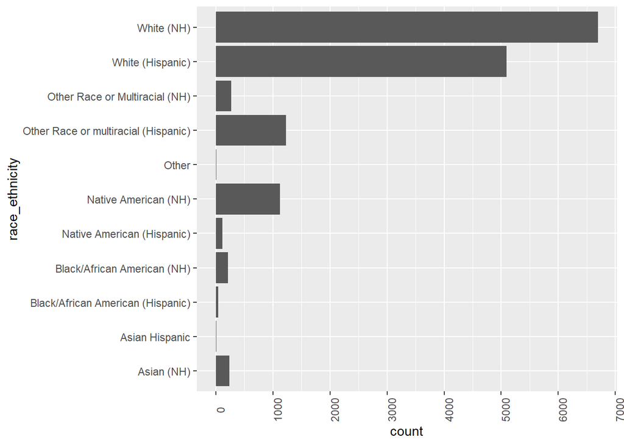

```r
ggplot(assignment3_vars, aes(x = race_ethnicity)) +
  geom_bar() +
   theme(axis.text.x = element_text(angle = 90)) +
    scale_y_continuous(breaks = seq(0,8000, by = 1000),
                     labels = paste(seq(0,8000, by = 1000),
                     "", sep = "")) +
  coord_flip()
```

### Wanted to get the numbers of each

```r
#table(assignment3_vars$race_ethnicity)
count(assignment3_vars, 'race_ethnicity')
```

```
##                          race_ethnicity freq
## 1                            Asian (NH)  237
## 2                        Asian Hispanic    9
## 3     Black/African American (Hispanic)   43
## 4           Black/African American (NH)  212
## 5            Native American (Hispanic)  115
## 6                  Native American (NH) 1124
## 7                                 Other   14
## 8  Other Race or multiracial (Hispanic) 1232
## 9        Other Race or Multiracial (NH)  272
## 10                     White (Hispanic) 5091
## 11                           White (NH) 6694
```

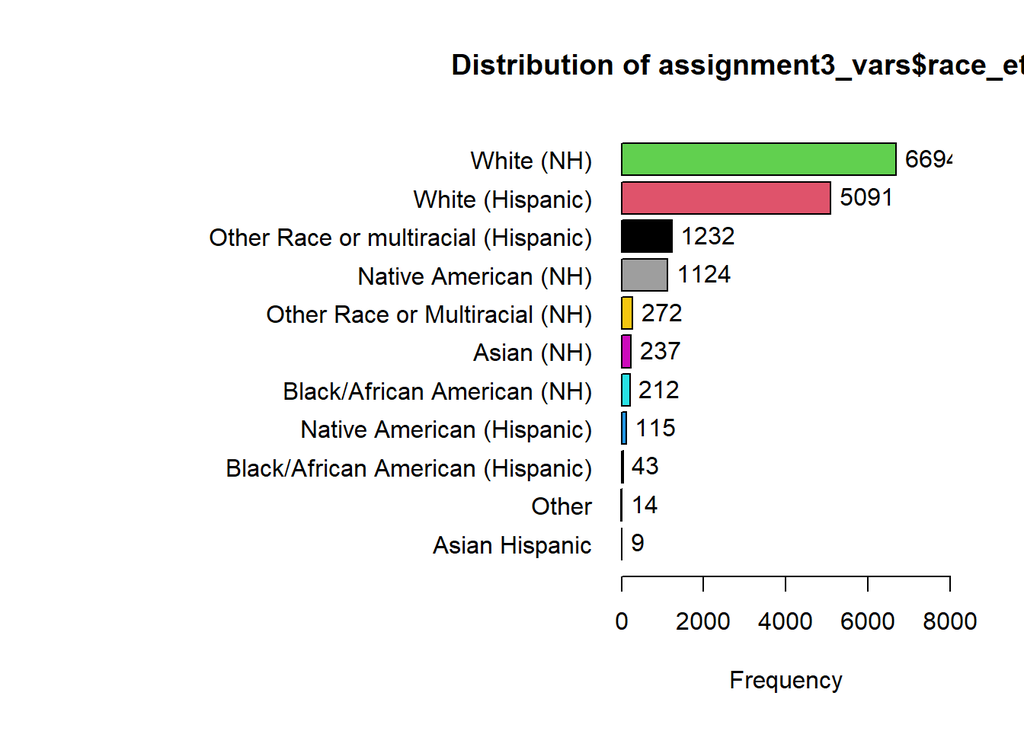

```
## assignment3_vars$race_ethnicity :
##                                      Frequency Percent Cum. percent
## White (NH)                                6694    44.5         44.5
## White (Hispanic)                          5091    33.8         78.3
## Other Race or multiracial (Hispanic)      1232     8.2         86.5
## Native American (NH)                      1124     7.5         94.0
## Other Race or Multiracial (NH)             272     1.8         95.8
## Asian (NH)                                 237     1.6         97.4
## Black/African American (NH)                212     1.4         98.8
## Native American (Hispanic)                 115     0.8         99.6
## Black/African American (Hispanic)           43     0.3         99.8
## Other                                       14     0.1         99.9
## Asian Hispanic                               9     0.1        100.0
##   Total                                  15043   100.0        100.0
```

```r
tab1(assignment3_vars$race_ethnicity, sort.group ="decreasing", cum.percent =TRUE)
```

## **Relationship Calculations:**

### References for Data Interpretation

SOME DUDE’s (J.D. EVANS) THOUGHTS ON CORRELATION STRENGTHS from 1996  
.00-.19 = very weak  
.20-.39 = weak  
.40-.59 = moderate  
.60-.79 = strong  
.80-1.0 = very strong

After a discussion with Julia, I decided to use these cutoffs to inform how I described my correlations.

### WHat is F and Pr in the ANOVA test Results?

The **F Value** in the ANOVA output is telling us that there is a difference in means (if it is greater than zero) and the **Pr** value is telling us the likelihood of that difference appearing in our data if there is not actually a difference

## **1. Household Income**

### 1.1 Household Income & Number of People in Household

**Type of Test**: Two continuous variables –> Pearson’s Correlation –> Will generate strength and significance of relationship.

```r
correlation_HINCP_NP <- cor.test(assignment3_vars$HINCP, assignment3_vars$NP)
correlation_HINCP_NP
```

```
##
##  Pearson's product-moment correlation
##
## data:  assignment3_vars$HINCP and assignment3_vars$NP
## t = 14.751, df = 15041, p-value < 2.2e-16
## alternative hypothesis: true correlation is not equal to 0
## 95 percent confidence interval:
##  0.1036371 0.1351422
## sample estimates:
##       cor
## 0.1194197
```

**Results interpreted**: The relationship is significant, thus there is a very weak positive relationship between Household Income and Number of People in Household. Roughly speaking, there is some indication that as the number of people in a household increases, so does income.

### 1.2 Household Income & Commute To Work

**Type of Test**: A continuous variable and a categorical variable with more than three levels –> Analysis of Variance Test (ANOVA) –> Will give the significance of the relationship

**QUestion for Grader** If you could point me to a resource to better understand the results of Tukeys HSD, I’d be appreciative.

```r
anova_HINCP_JWMNP <- aov(HINCP ~ JWMNP_binned, data = assignment3_vars)
summary(anova_HINCP_JWMNP)
```

```
##                 Df    Sum Sq   Mean Sq F value Pr(>F)
## JWMNP_binned     5 1.271e+12 2.541e+11   39.84 <2e-16 ***
## Residuals    15037 9.591e+13 6.378e+09
## ---
## Signif. codes:  0 '***' 0.001 '**' 0.01 '*' 0.05 '.' 0.1 ' ' 1
```

```r
# Calculate Tukey's Honestly Signigicant Difference Test
differences_HINCP_JWMNP <- TukeyHSD(anova_HINCP_JWMNP)

as_tibble(cbind(pair=row.names(differences_HINCP_JWMNP$HINCP),differences_HINCP_JWMNP$JWMNP))
```

```
## # A tibble: 15 x 4
##       diff     lwr     upr      `p adj`
##      <dbl>   <dbl>   <dbl>        <dbl>
##  1   8328.  -1892.  18548. 0.185
##  2  -3081. -18320.  12157. 0.993
##  3   5449. -29167.  40065. 0.998
##  4 -18577. -23631. -13523. 0.0000000115
##  5   2196.  -6920.  11312. 0.983
##  6 -11410. -28590.   5771. 0.407
##  7  -2879. -38393.  32634. 1.00
##  8 -26905. -36312. -17498. 0.0000000115
##  9  -6132. -18217.   5953. 0.699
## 10   8530. -28739.  45799. 0.987
## 11 -15496. -30202.   -790. 0.0320
## 12   5277. -11270.  21825. 0.944
## 13 -24026. -58411.  10359. 0.347
## 14  -3253. -38465.  31959. 1.00
## 15  20773.  12579.  28967. 0.0000000115
```

```r
differences_HINCP_JWMNP
```

```
##   Tukey multiple comparisons of means
##     95% family-wise confidence level
##
## Fit: aov(formula = HINCP ~ JWMNP_binned, data = assignment3_vars)
##
## $JWMNP_binned
##                                                diff        lwr         upr
## 30 - 45 minutes-15 - 30 minutes            8328.157  -1891.942  18548.2553
## 45 - 60 minutes-15 - 30 minutes           -3081.452 -18320.308  12157.4045
## 60 - 75 minutes-15 - 30 minutes            5448.742 -29167.321  40064.8058
## Less Than 15 minutes-15 - 30 minutes     -18577.009 -23631.067 -13522.9513
## No Commute Reported-15 - 30 minutes        2195.743  -6920.016  11311.5018
## 45 - 60 minutes-30 - 45 minutes          -11409.608 -28590.253   5771.0366
## 60 - 75 minutes-30 - 45 minutes           -2879.414 -38393.126  32634.2968
## Less Than 15 minutes-30 - 45 minutes     -26905.166 -36312.361 -17497.9706
## No Commute Reported-30 - 45 minutes       -6132.414 -18217.482   5952.6549
## 60 - 75 minutes-45 - 60 minutes            8530.194 -28739.043  45799.4305
## Less Than 15 minutes-45 - 60 minutes     -15495.558 -30201.599   -789.5167
## No Commute Reported-45 - 60 minutes        5277.194 -11270.349  21824.7382
## Less Than 15 minutes-60 - 75 minutes     -24025.752 -58410.585  10359.0817
## No Commute Reported-60 - 75 minutes       -3252.999 -38464.792  31958.7930
## No Commute Reported-Less Than 15 minutes  20772.752  12578.732  28966.7728
##                                              p adj
## 30 - 45 minutes-15 - 30 minutes          0.1849630
## 45 - 60 minutes-15 - 30 minutes          0.9925806
## 60 - 75 minutes-15 - 30 minutes          0.9977226
## Less Than 15 minutes-15 - 30 minutes     0.0000000
## No Commute Reported-15 - 30 minutes      0.9834938
## 45 - 60 minutes-30 - 45 minutes          0.4065947
## 60 - 75 minutes-30 - 45 minutes          0.9999104
## Less Than 15 minutes-30 - 45 minutes     0.0000000
## No Commute Reported-30 - 45 minutes      0.6985580
## 60 - 75 minutes-45 - 60 minutes          0.9868947
## Less Than 15 minutes-45 - 60 minutes     0.0320213
## No Commute Reported-45 - 60 minutes      0.9443755
## Less Than 15 minutes-60 - 75 minutes     0.3471810
## No Commute Reported-60 - 75 minutes      0.9998294
## No Commute Reported-Less Than 15 minutes 0.0000000
```

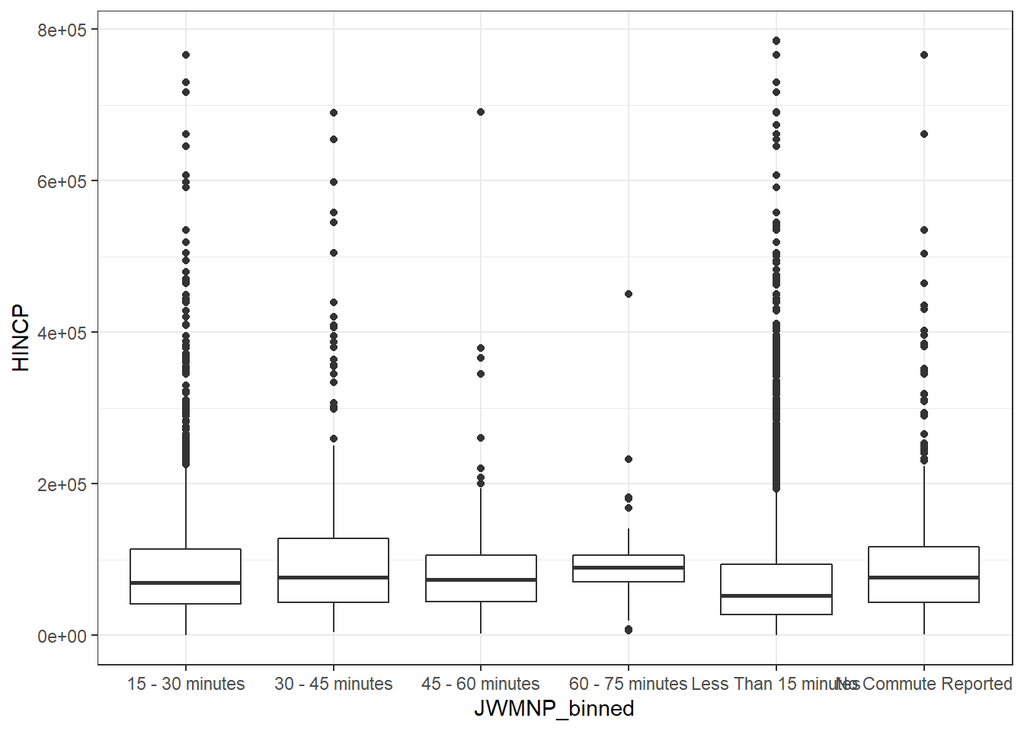

```r
ggplot(assignment3_vars, aes(x=JWMNP_binned, y=HINCP)) +
  geom_boxplot() +
  theme_bw()
```

### 1.3 Household Income & Age of Person

**Type of Test**: Two continuous variables –> Pearson’s Correlation –> Will generate strength and significance of relationship.

```r
correlation_HINCP_AGEP <- cor.test(assignment3_vars$HINCP, assignment3_vars$AGEP)
correlation_HINCP_AGEP
```

```
##
##  Pearson's product-moment correlation
##
## data:  assignment3_vars$HINCP and assignment3_vars$AGEP
## t = 2.2292, df = 15041, p-value = 0.02581
## alternative hypothesis: true correlation is not equal to 0
## 95 percent confidence interval:
##  0.002194014 0.034144227
## sample estimates:
##        cor
## 0.01817376
```

**Analysis of Results**: This test is showing that there is a significantly significant (within the 95% confidence interval), but VERY weak correlation between Household Income and Age of Person. When I graph this, it makes sense that there is no readily apparent relationship. Although I think without looking at the Data I would have expected there to be one.

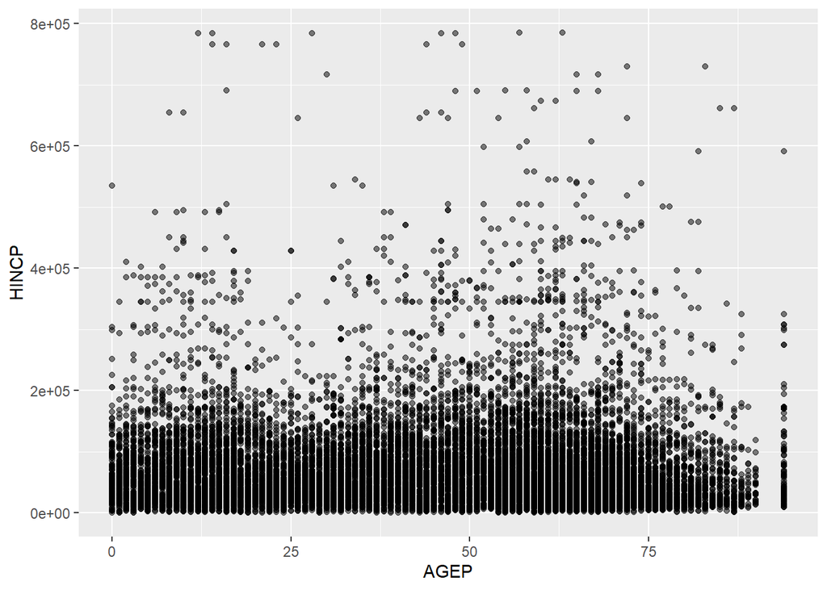

```r
ggplot(assignment3_vars, aes(AGEP, HINCP)) +
  geom_point(alpha=.5, sixe =5)
```

### 1.4 Household Income & Decade House Constructed

**Type of Test**: A continuous variable and a categorical variable with more than three levels –> Analysis of Variance Test (ANOVA) –> Will give the significance of the relationship

```r
anova_HINCP_development <- aov(HINCP ~ development, data = assignment3_vars)
summary(anova_HINCP_development)
```

```
##                Df   Sum Sq   Mean Sq F value Pr(>F)
## development     8 1.48e+12 1.851e+11   29.07 <2e-16 ***
## Residuals   15034 9.57e+13 6.366e+09
## ---
## Signif. codes:  0 '***' 0.001 '**' 0.01 '*' 0.05 '.' 0.1 ' ' 1
```

**Analysis of Results**: The relationship is significant. The relationship between these variables is not due to chance since the inverse would only happen once in 2e-16 times of running the correlation.

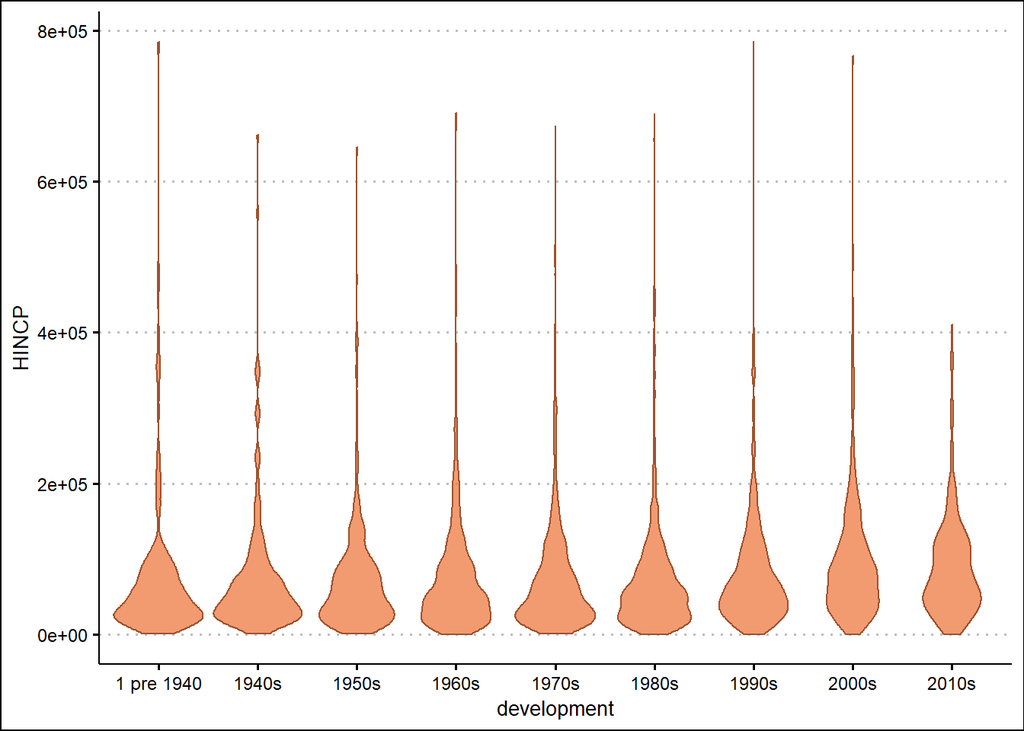

```r
ggplot(assignment3_vars, aes(x=development, y=HINCP)) +
         geom_violin(color="sienna", fill ="sienna2", alpha=.75, size =.5) +
  theme_clean()
```

### 1.5 Household Income & Race_Ethnicity

**Type of Test**: A continuous variable and a categorical variable with more than three levels –> Analysis of Variance Test (ANOVA) –> Will give the significance of the relationship

```r
anova_HINCP_race_ethnicity <- aov(HINCP ~ race_ethnicity, data = assignment3_vars)
summary(anova_HINCP_race_ethnicity)
```

```
##                   Df    Sum Sq   Mean Sq F value Pr(>F)
## race_ethnicity    10 3.883e+12 3.883e+11   62.57 <2e-16 ***
## Residuals      15032 9.330e+13 6.207e+09
## ---
## Signif. codes:  0 '***' 0.001 '**' 0.01 '*' 0.05 '.' 0.1 ' ' 1
```

**Analysis of Results**: The relationship is significant. The relationship between these variables is not due to chance since the inverse would only happen once in 2e-16 times of running the correlation.

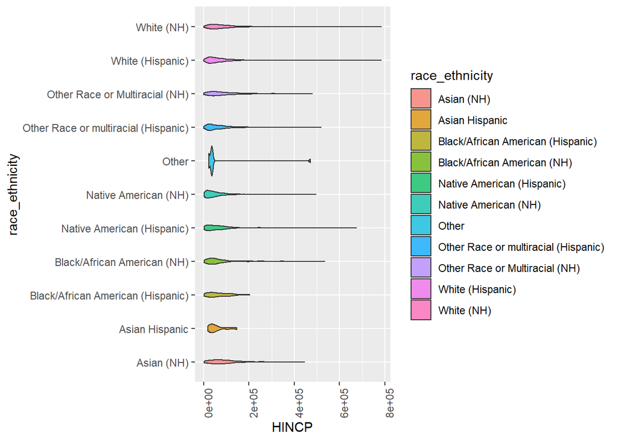

```r
ggplot(assignment3_vars, aes(x=race_ethnicity, y=HINCP, fill=race_ethnicity)) +
         geom_violin(alpha=.75, size =.5) +
  theme(axis.text.x = element_text(angle = 90)) +
  coord_flip()
```

## **2. Number of People in House**

### 2.1 Number of People in House & Income

See 1.1

### 2.2 Number of People in House & Commute to Work

**Type of Test**: A continuous variable and a categorical variable with more than three levels –> Analysis of Variance Test (ANOVA) –> Will give the significance of the relationship

```r
anova_NP_JWMNP <- aov(NP ~ JWMNP_binned, data = assignment3_vars)
summary(anova_NP_JWMNP)
```

```
##                 Df Sum Sq Mean Sq F value  Pr(>F)
## JWMNP_binned     5    226   45.28   15.47 3.3e-15 ***
## Residuals    15037  44018    2.93
## ---
## Signif. codes:  0 '***' 0.001 '**' 0.01 '*' 0.05 '.' 0.1 ' ' 1
```

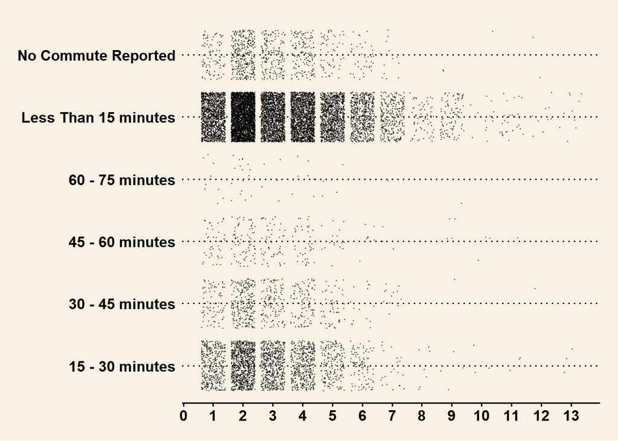

```r
ggplot(assignment3_vars, aes(x=NP, y=JWMNP_binned)) +
  geom_point(position = "jitter", size =.25, alpha =.5) +
  scale_x_continuous(breaks = seq(0,13, by = 1),
                     labels = paste(seq(0,13, by = 1),
                     "", sep = "")) +
   theme_wsj()
```

### 2.3 Number of People in House & Age of Person

**Type of Test**: Two Continuous Variables –> Pearson’s Correlation –> Will give us both significance and strength of correlation

```r
correlation_NP_AGEP <- cor.test(assignment3_vars$NP, assignment3_vars$AGEP)
correlation_NP_AGEP
```

```
##
##  Pearson's product-moment correlation
##
## data:  assignment3_vars$NP and assignment3_vars$AGEP
## t = -71.775, df = 15041, p-value < 2.2e-16
## alternative hypothesis: true correlation is not equal to 0
## 95 percent confidence interval:
##  -0.5169077 -0.4930994
## sample estimates:
##        cor
## -0.5050996
```

**Analysis of Results** This test tells us that there is a significant relationship between number of people in house and the Age of Person. The correlation is a moderate inverse relationship. So as age increases, the number of people in household tends to decrease. This makes sense given that basically no-one in the dataset under ~18 years old is living alone.

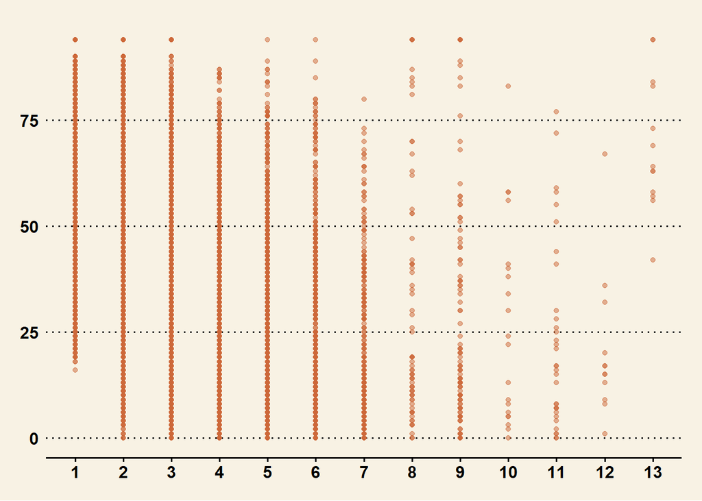

```r
ggplot(assignment3_vars, aes(AGEP, NP)) +
  geom_point(alpha=.5, sixe =25, color="Sienna3") +
   scale_y_continuous(name ="Number of People Living Together",
                      breaks = seq(0,13, by = 1),
                     labels = paste(seq(0,13, by = 1),
                     "", sep = "")) +
  coord_flip() +
  theme_wsj()
```

### 2.4 Number of People in House & Decade House Constructed

**Type of Test**: A continuous and categorical variable with more than 3 levels –> ANOVA test –> Significance of the Relationship

```r
anova_NP_development <- aov(NP ~ development, data = assignment3_vars)
summary(anova_NP_development)
```

```
##                Df Sum Sq Mean Sq F value Pr(>F)
## development     8    335   41.91   14.35 <2e-16 ***
## Residuals   15034  43909    2.92
## ---
## Signif. codes:  0 '***' 0.001 '**' 0.01 '*' 0.05 '.' 0.1 ' ' 1
```

```r
# Calculate Tukey's Honestly Signigicant Difference Test
differences_NP_development <- TukeyHSD(anova_NP_development)
as_tibble(cbind(pair=row.names(differences_NP_development$NP),differences_NP_development$development))
```

```
## # A tibble: 36 x 4
##     diff     lwr   upr      `p adj`
##    <dbl>   <dbl> <dbl>        <dbl>
##  1 0.132 -0.178  0.441 0.926
##  2 0.292  0.0410 0.543 0.00936
##  3 0.550  0.302  0.798 0.0000000117
##  4 0.310  0.0796 0.540 0.000998
##  5 0.417  0.188  0.646 0.000000602
##  6 0.420  0.192  0.648 0.000000437
##  7 0.600  0.368  0.832 0.0000000114
##  8 0.588  0.305  0.871 0.0000000160
##  9 0.160 -0.113  0.434 0.671
## 10 0.418  0.147  0.689 0.0000598
## # ... with 26 more rows
```

```r
differences_NP_development
```

```
##   Tukey multiple comparisons of means
##     95% family-wise confidence level
##
## Fit: aov(formula = NP ~ development, data = assignment3_vars)
##
## $development
##                          diff         lwr         upr     p adj
## 1940s-1 pre 1940  0.131615762 -0.17779248  0.44102400 0.9257991
## 1950s-1 pre 1940  0.291898168  0.04101488  0.54278146 0.0093628
## 1960s-1 pre 1940  0.549817400  0.30184784  0.79778696 0.0000000
## 1970s-1 pre 1940  0.309656386  0.07961410  0.53969868 0.0009975
## 1980s-1 pre 1940  0.416702409  0.18783553  0.64556929 0.0000006
## 1990s-1 pre 1940  0.419933086  0.19156886  0.64829731 0.0000004
## 2000s-1 pre 1940  0.600144780  0.36845900  0.83183056 0.0000000
## 2010s-1 pre 1940  0.588031421  0.30459071  0.87147213 0.0000000
## 1950s-1940s       0.160282406 -0.11339455  0.43395936 0.6710124
## 1960s-1940s       0.418201638  0.14719323  0.68921004 0.0000598
## 1970s-1940s       0.178040624 -0.07666726  0.43274851 0.4265668
## 1980s-1940s       0.285086647  0.03143984  0.53873345 0.0144637
## 1990s-1940s       0.288317324  0.03512397  0.54151067 0.0123207
## 2000s-1940s       0.468529018  0.21233582  0.72472221 0.0000005
## 2010s-1940s       0.456415659  0.15261427  0.76021705 0.0001106
## 1960s-1950s       0.257919233  0.05628957  0.45954890 0.0023650
## 1970s-1950s       0.017758218 -0.16136485  0.19688128 0.9999977
## 1980s-1950s       0.124804241 -0.05280676  0.30241524 0.4189213
## 1990s-1950s       0.128034918 -0.04892790  0.30499774 0.3766968
## 2000s-1950s       0.308246613  0.12701770  0.48947553 0.0000048
## 2010s-1950s       0.296133253  0.05219832  0.54006819 0.0052314
## 1970s-1960s      -0.240161015 -0.41517974 -0.06514229 0.0007030
## 1980s-1960s      -0.133114992 -0.30658587  0.04035589 0.2946729
## 1990s-1960s      -0.129884315 -0.30269149  0.04292286 0.3229385
## 2000s-1960s       0.050327380 -0.12684598  0.22750074 0.9939543
## 2010s-1960s       0.038214021 -0.20272317  0.27915122 0.9999130
## 1980s-1970s       0.107046023 -0.03966014  0.25375218 0.3645946
## 1990s-1970s       0.110276700 -0.03564406  0.25619746 0.3154149
## 2000s-1970s       0.290488395  0.13942235  0.44155444 0.0000001
## 2010s-1970s       0.278375035  0.05593115  0.50081892 0.0033345
## 1990s-1980s       0.003230677 -0.14082995  0.14729130 1.0000000
## 2000s-1980s       0.183442372  0.03417233  0.33271241 0.0043792
## 2010s-1980s       0.171329012 -0.04989910  0.39255712 0.2824317
## 2000s-1990s       0.180211695  0.03171349  0.32870990 0.0052577
## 2010s-1990s       0.168098335 -0.05260973  0.38880640 0.3047930
## 2010s-2000s      -0.012113359 -0.23625646  0.21202974 1.0000000
```

**Analysis of Test**: The ANOVA test shows that there is a statistically significant correlation between Number of People and Decade the home was built in.

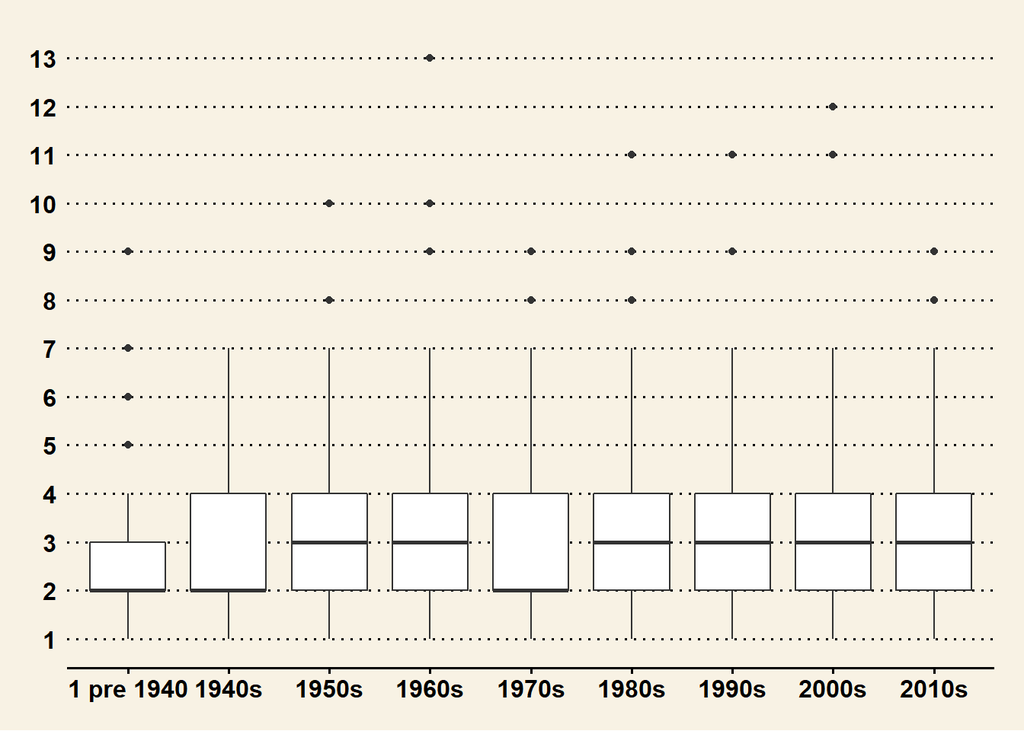

```r
ggplot(assignment3_vars,aes( x= development, y=NP)) +
  scale_y_continuous(name ="Number of People Living Together",
                      breaks = seq(0,13, by = 1),
                     labels = paste(seq(0,13, by = 1),
                     "", sep = ""))+
  geom_boxplot() +
  theme_wsj()
```

## **3. Commute to Work**

### 3.1 Commute to Work & Income

See 1.2

### 3.2 Commute to Work & Number of People in House

See 2.2

### 3.3 Commute to Work & Age of Person

**Type of Test**: Categorical Variable & Continuous variable –> ANOVA Test –> Will give significance of relationship.

```r
anova_JWMNP_AGEP <- aov(AGEP ~JWMNP_binned , data = assignment3_vars)
summary(anova_JWMNP_AGEP)
```

```
##                 Df  Sum Sq Mean Sq F value Pr(>F)
## JWMNP_binned     5    2013   402.6   0.705  0.619
## Residuals    15037 8582611   570.8
```

```r
# Calculate Tukey's Honestly Signigicant Difference Test
differences_JWMNP_AGEP <- TukeyHSD(anova_JWMNP_AGEP)
as_tibble(cbind(pair=row.names(differences_JWMNP_AGEP$JWMNP),differences_JWMNP_AGEP$AGEP))
```

```
## # A tibble: 15 x 1
##    pair
##    <chr>
##  1 30 - 45 minutes-15 - 30 minutes
##  2 45 - 60 minutes-15 - 30 minutes
##  3 60 - 75 minutes-15 - 30 minutes
##  4 Less Than 15 minutes-15 - 30 minutes
##  5 No Commute Reported-15 - 30 minutes
##  6 45 - 60 minutes-30 - 45 minutes
##  7 60 - 75 minutes-30 - 45 minutes
##  8 Less Than 15 minutes-30 - 45 minutes
##  9 No Commute Reported-30 - 45 minutes
## 10 60 - 75 minutes-45 - 60 minutes
## 11 Less Than 15 minutes-45 - 60 minutes
## 12 No Commute Reported-45 - 60 minutes
## 13 Less Than 15 minutes-60 - 75 minutes
## 14 No Commute Reported-60 - 75 minutes
## 15 No Commute Reported-Less Than 15 minutes
```

```r
differences_JWMNP_AGEP
```

```
##   Tukey multiple comparisons of means
##     95% family-wise confidence level
##
## Fit: aov(formula = AGEP ~ JWMNP_binned, data = assignment3_vars)
##
## $JWMNP_binned
##                                                diff        lwr       upr
## 30 - 45 minutes-15 - 30 minutes           0.5625277  -2.494711  3.619766
## 45 - 60 minutes-15 - 30 minutes           1.2943532  -3.264196  5.852902
## 60 - 75 minutes-15 - 30 minutes           2.7488987  -7.606145 13.103943
## Less Than 15 minutes-15 - 30 minutes     -0.1551702  -1.667040  1.356700
## No Commute Reported-15 - 30 minutes       0.9899008  -1.736986  3.716788
## 45 - 60 minutes-30 - 45 minutes           0.7318255  -4.407590  5.871241
## 60 - 75 minutes-30 - 45 minutes           2.1863710  -8.437195 12.809937
## Less Than 15 minutes-30 - 45 minutes     -0.7176979  -3.531765  2.096369
## No Commute Reported-30 - 45 minutes       0.4273731  -3.187753  4.042499
## 60 - 75 minutes-45 - 60 minutes           1.4545455  -9.694168 12.603259
## Less Than 15 minutes-45 - 60 minutes     -1.4495235  -5.848686  2.949639
## No Commute Reported-45 - 60 minutes      -0.3044525  -5.254482  4.645577
## Less Than 15 minutes-60 - 75 minutes     -2.9040689 -13.189943  7.381805
## No Commute Reported-60 - 75 minutes      -1.7589979 -12.292248  8.774252
## No Commute Reported-Less Than 15 minutes  1.1450710  -1.306087  3.596229
##                                              p adj
## 30 - 45 minutes-15 - 30 minutes          0.9952256
## 45 - 60 minutes-15 - 30 minutes          0.9659390
## 60 - 75 minutes-15 - 30 minutes          0.9745779
## Less Than 15 minutes-15 - 30 minutes     0.9997139
## No Commute Reported-15 - 30 minutes      0.9063614
## 45 - 60 minutes-30 - 45 minutes          0.9985922
## 60 - 75 minutes-30 - 45 minutes          0.9919497
## Less Than 15 minutes-30 - 45 minutes     0.9786967
## No Commute Reported-30 - 45 minutes      0.9994289
## 60 - 75 minutes-45 - 60 minutes          0.9990777
## Less Than 15 minutes-45 - 60 minutes     0.9363892
## No Commute Reported-45 - 60 minutes      0.9999772
## Less Than 15 minutes-60 - 75 minutes     0.9667605
## No Commute Reported-60 - 75 minutes      0.9969810
## No Commute Reported-Less Than 15 minutes 0.7675600
```

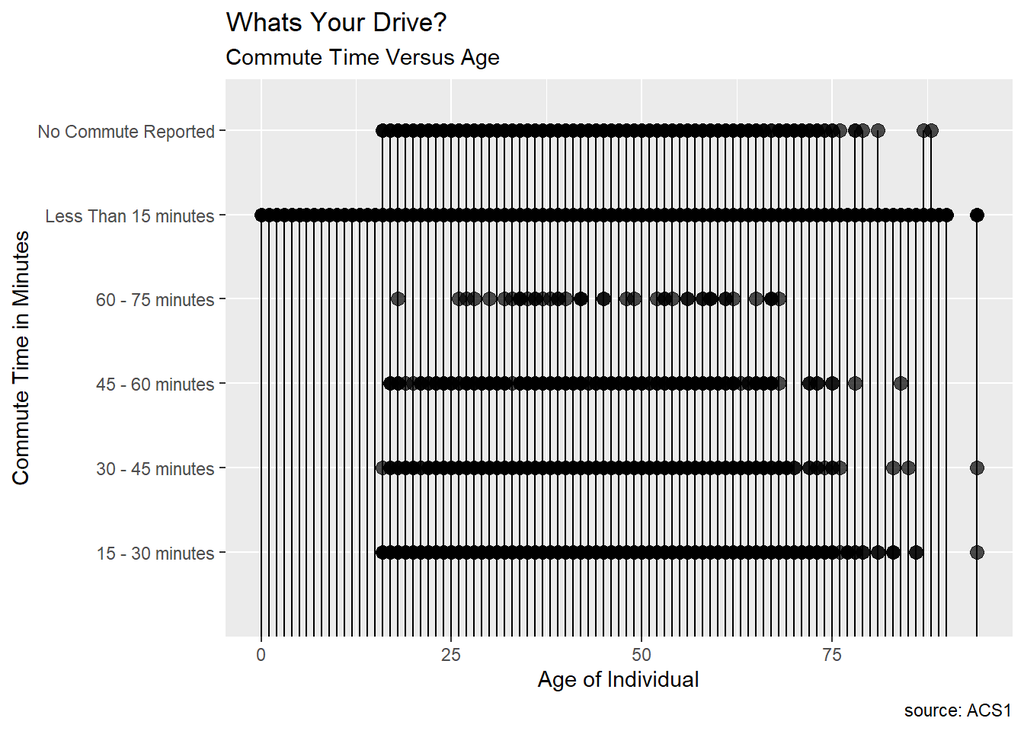

```r
ggplot(assignment3_vars,aes(x=AGEP, y=JWMNP_binned)) +
  geom_point(size=3,alpha=.7) +
  geom_segment(aes(x=AGEP,
                   xend=AGEP,
                   y=0,
                   yend=JWMNP_binned)) +
  labs(title="Whats Your Drive?",
       subtitle="Commute Time Versus Age",
       caption="source: ACS1") +
  scale_y_discrete(name="Commute Time in Minutes") +
  scale_x_continuous(name="Age of Individual")
```

```r
  theme(axis.text.x = element_text(angle=65, vjust=0.6)) +
    theme_fivethirtyeight()
```

**Analysis of Test**: The Anova test shows that there is not a statistically significant correlation between Age and Commute time to work. This seems to match the graph.

### 3.4 Commute to Work & Decade House Constructed

**Type Of Test**: Two categorical variables –> Chi-Squared Test –> Will give significance

```r
chi_sq <- chisq.test(assignment3_vars$development, assignment3_vars$JWMNP_binned)
chi_sq
```

```
##
##  Pearson's Chi-squared test
##
## data:  assignment3_vars$development and assignment3_vars$JWMNP_binned
## X-squared = 145.25, df = 40, p-value = 7.302e-14
```

```r
#Observed
chi_sq$observed
```

```
##                             assignment3_vars$JWMNP_binned
## assignment3_vars$development 15 - 30 minutes 30 - 45 minutes 45 - 60 minutes
##                   1 pre 1940              84              17               9
##                   1940s                   80              20               8
##                   1950s                  212              24              21
##                   1960s                  212              43              19
##                   1970s                  410              97              33
##                   1980s                  450             106              37
##                   1990s                  494             144              57
##                   2000s                  420             141              46
##                   2010s                  135              27              15
##                             assignment3_vars$JWMNP_binned
## assignment3_vars$development 60 - 75 minutes Less Than 15 minutes
##                   1 pre 1940               3                  532
##                   1940s                    2                  384
##                   1950s                    4                 1017
##                   1960s                    3                 1094
##                   1970s                    4                 1874
##                   1980s                   10                 1940
##                   1990s                    8                 1873
##                   2000s                    9                 1595
##                   2010s                    1                  498
##                             assignment3_vars$JWMNP_binned
## assignment3_vars$development No Commute Reported
##                   1 pre 1940                  26
##                   1940s                       28
##                   1950s                       57
##                   1960s                       63
##                   1970s                      130
##                   1980s                      136
##                   1990s                      163
##                   2000s                      173
##                   2010s                       55
```

```r
#Expected
chi_sq$expected
```

```
##                             assignment3_vars$JWMNP_binned
## assignment3_vars$development 15 - 30 minutes 30 - 45 minutes 45 - 60 minutes
##                   1 pre 1940       111.37984        27.61078       10.928339
##                   1940s             86.64721        21.47963        8.501629
##                   1950s            221.59775        54.93352       21.742671
##                   1960s            238.03084        59.00725       23.355049
##                   1970s            422.94463       104.84691       41.498371
##                   1980s            444.68942       110.23739       43.631922
##                   1990s            454.64887       112.70631       44.609121
##                   2000s            395.72213        98.09852       38.827362
##                   2010s            121.33929        30.07970       11.905537
##                             assignment3_vars$JWMNP_binned
## assignment3_vars$development 60 - 75 minutes Less Than 15 minutes
##                   1 pre 1940        1.962640             482.0513
##                   1940s             1.526823             375.0086
##                   1950s             3.904806             959.0737
##                   1960s             4.194376            1030.1960
##                   1970s             7.452769            1830.5016
##                   1980s             7.835937            1924.6130
##                   1990s             8.011434            1967.7174
##                   2000s             6.973077            1712.6828
##                   2010s             2.138137             525.1557
##                             assignment3_vars$JWMNP_binned
## assignment3_vars$development No Commute Reported
##                   1 pre 1940            37.06714
##                   1940s                 28.83614
##                   1950s                 73.74759
##                   1960s                 79.21651
##                   1970s                140.75570
##                   1980s                147.99236
##                   1990s                151.30685
##                   2000s                131.69607
##                   2010s                 40.38164
```

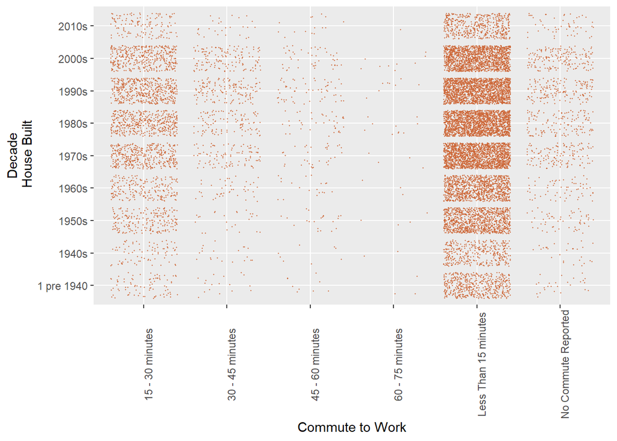

```r
ggplot(assignment3_vars, aes(x=JWMNP_binned, y=development)) +
  theme(axis.text.x = element_text(angle = 90)) +
  geom_point(position ="jitter", alpha =.75, color="sienna3", size=.25) +
  scale_x_discrete( name= "Commute to Work") +
  scale_y_discrete( name ="Decade\n House Built")
```

**Analysis of Test**: The Chi-Squared Test indicated that there is a significant relationship between Commute to Work and Decade Home was built.

### 3.5 Commute to Work & Race and Ethnicity

**Type of Test**: Two Categorical variables –> Chi-Squared Test –> Significance of Relationship

```r
chi_sq_race_JWMNP <- chisq.test(assignment3_vars$JWMNP_binned, assignment3_vars$race_ethnicity)
chi_sq_race_JWMNP
```

```
##
##  Pearson's Chi-squared test
##
## data:  assignment3_vars$JWMNP_binned and assignment3_vars$race_ethnicity
## X-squared = 107.83, df = 50, p-value = 3.968e-06
```

```r
#Observed
chi_sq_race_JWMNP$observed
```

```
##
## assignment3_vars$JWMNP_binned Asian (NH) Asian Hispanic
##          15 - 30 minutes              53              1
##          30 - 45 minutes               9              2
##          45 - 60 minutes               4              0
##          60 - 75 minutes               1              0
##          Less Than 15 minutes        152              5
##          No Commute Reported          18              1
##
## assignment3_vars$JWMNP_binned Black/African American (Hispanic)
##          15 - 30 minutes                                      5
##          30 - 45 minutes                                      3
##          45 - 60 minutes                                      0
##          60 - 75 minutes                                      0
##          Less Than 15 minutes                                34
##          No Commute Reported                                  1
##
## assignment3_vars$JWMNP_binned Black/African American (NH)
##          15 - 30 minutes                               46
##          30 - 45 minutes                                8
##          45 - 60 minutes                                4
##          60 - 75 minutes                                0
##          Less Than 15 minutes                         135
##          No Commute Reported                           19
##
## assignment3_vars$JWMNP_binned Native American (Hispanic) Native American (NH)
##          15 - 30 minutes                              13                  142
##          30 - 45 minutes                               4                   64
##          45 - 60 minutes                               1                   19
##          60 - 75 minutes                               0                    1
##          Less Than 15 minutes                         94                  848
##          No Commute Reported                           3                   50
##
## assignment3_vars$JWMNP_binned Other Other Race or multiracial (Hispanic)
##          15 - 30 minutes          2                                  199
##          30 - 45 minutes          0                                   76
##          45 - 60 minutes          0                                   25
##          60 - 75 minutes          0                                    3
##          Less Than 15 minutes    11                                  850
##          No Commute Reported      1                                   79
##
## assignment3_vars$JWMNP_binned Other Race or Multiracial (NH) White (Hispanic)
##          15 - 30 minutes                                  44              845
##          30 - 45 minutes                                  10              195
##          45 - 60 minutes                                   9               78
##          60 - 75 minutes                                   1               10
##          Less Than 15 minutes                            201             3644
##          No Commute Reported                               7              319
##
## assignment3_vars$JWMNP_binned White (NH)
##          15 - 30 minutes            1147
##          30 - 45 minutes             248
##          45 - 60 minutes             105
##          60 - 75 minutes              28
##          Less Than 15 minutes       4833
##          No Commute Reported         333
```

```r
#Expected
chi_sq_race_JWMNP$expected
```

```
##
## assignment3_vars$JWMNP_binned  Asian (NH) Asian Hispanic
##          15 - 30 minutes       39.3398258     1.49391744
##          30 - 45 minutes        9.7522436     0.37033836
##          45 - 60 minutes        3.8599349     0.14657980
##          60 - 75 minutes        0.6932128     0.02632454
##          Less Than 15 minutes 170.2625141     6.46566509
##          No Commute Reported   13.0922688     0.49717477
##
## assignment3_vars$JWMNP_binned Black/African American (Hispanic)
##          15 - 30 minutes                              7.1376055
##          30 - 45 minutes                              1.7693944
##          45 - 60 minutes                              0.7003257
##          60 - 75 minutes                              0.1257728
##          Less Than 15 minutes                        30.8915110
##          No Commute Reported                          2.3753905
##
## assignment3_vars$JWMNP_binned Black/African American (NH)
##          15 - 30 minutes                       35.1900552
##          30 - 45 minutes                        8.7235259
##          45 - 60 minutes                        3.4527687
##          60 - 75 minutes                        0.6200891
##          Less Than 15 minutes                 152.3023333
##          No Commute Reported                   11.7112278
##
## assignment3_vars$JWMNP_binned Native American (Hispanic) Native American (NH)
##          15 - 30 minutes                      19.0889450           186.573689
##          30 - 45 minutes                       4.7321013            46.251147
##          45 - 60 minutes                       1.8729642            18.306189
##          60 - 75 minutes                       0.3363691             3.287642
##          Less Than 15 minutes                 82.6168317           807.489729
##          No Commute Reported                   6.3527887            62.091604
##
## assignment3_vars$JWMNP_binned       Other Other Race or multiracial (Hispanic)
##          15 - 30 minutes       2.32387157                           204.500698
##          30 - 45 minutes       0.57608190                            50.695207
##          45 - 60 minutes       0.22801303                            20.065147
##          60 - 75 minutes       0.04094928                             3.603537
##          Less Than 15 minutes 10.05770126                           885.077711
##          No Commute Reported   0.77338297                            68.057701
##
## assignment3_vars$JWMNP_binned Other Race or Multiracial (NH) White (Hispanic)
##          15 - 30 minutes                           45.149505        845.05930
##          30 - 45 minutes                           11.192448        209.48807
##          45 - 60 minutes                            4.429967         82.91531
##          60 - 75 minutes                            0.795586         14.89091
##          Less Than 15 minutes                     195.406767       3657.41122
##          No Commute Reported                       15.025726        281.23519
##
## assignment3_vars$JWMNP_binned White (NH)
##          15 - 30 minutes      1111.14259
##          30 - 45 minutes       275.44944
##          45 - 60 minutes       109.02280
##          60 - 75 minutes        19.57961
##          Less Than 15 minutes 4809.01802
##          No Commute Reported   369.78754
```

**Analysis of Test**: The Chi-Squared Test indicated that there is a significant relationship between Race & Ethnicity and Commute to work.

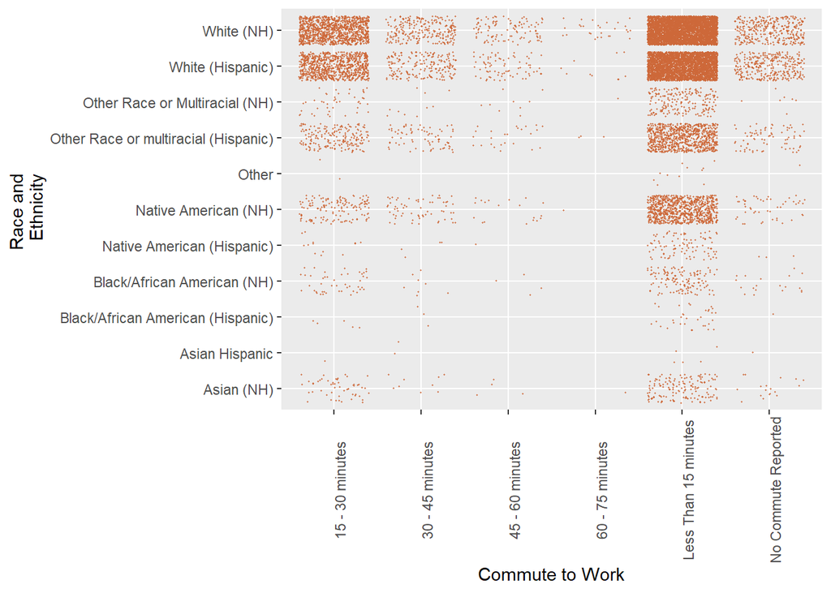

```r
ggplot(assignment3_vars, aes(x=JWMNP_binned, y=race_ethnicity)) +
  theme(axis.text.x = element_text(angle = 90)) +
  geom_point(position ="jitter", alpha =.75, color="sienna3", size=.25) +
  scale_x_discrete( name= "Commute to Work") +
  scale_y_discrete( name ="Race and \n Ethnicity")
```